# Enclosure indexes

```r
library(monitoR)
```

# Entropy

This is based on @brereton-2022. First we count the number of observations in each grid. Then we have

*p*<sub>*i*</sub> = *X*<sub>*i*</sub>/*N*, *i* = 1, …, *k*

where *p*<sub>*i*</sub> is the proportion of observation in grid *i*, *X*<sub>*i*</sub> is the number of observations in grid *i*, and finally *N* is the total number of observations.

The entropy is then
$$E_i = -\sum^k_{i = 1}p_i\log_{10}(p_i)$$

- Note that we use Base 10 log, originally entropy is base 2, but the behaviourists seem to use 10,
- we define 0log<sub>10</sub>(0) = 0, and
- This lies between 0 and *l**o**g*<sub>10</sub>(*k*)

If all the observations lie in one grid then we have

−(0 + 0 + … + 1log<sub>10</sub>(1) + … + 0) = 0

If the data is evenly spread, then

$$p_i = \frac{1}{k}$$

So we have

$$-\sum^k_{i = 1}\frac{1}{k}\log_{10}\left(\frac{1}{k}\right)
= \sum^k_{i = 1}\frac{1}{k}\log_{10}(k)
= \log_{10}(k)$$

# Modified spread of participation index (SPI)

From @plowman-2003, we have

$$SPI = \frac{\sum_{i = 1}^k\mid f^o_i - f^e_i \mid}{2(N - \min_{i = 1, \dots, k}(f^e_{i}))},$$

where

- *k* is the number of zones,
- *f*<sub>*i*</sub><sup>*o*</sup> is the observed frequency in zone *i*,
- *f*<sub>*i*</sub><sup>*e*</sup> is the expected frequency in zone *i*,
- *N* is the total number of observations:

$$N= \sum^k_{i = 1}f_i^o$$

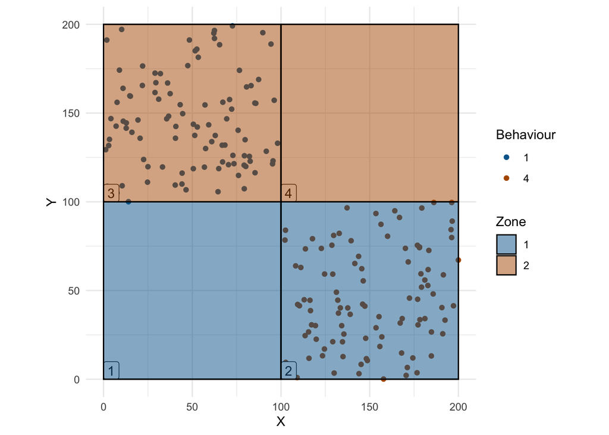

Figure 1: Simulated dataset with even spread

For even spread, we should have a SPI of zero. To test this, consider the simulated data given in Figure 1, in this case, we have four grids, two with 100 points each - Grid 2 and Grid 3. Also we have two zones:

- Zone 1: Grid 1 and Grid 2,
- Zone 2: Grid 3 and Grid 4.

In this case, we have

- *k* = 2,
- *f*<sub>1</sub><sup>*o*</sup> = *f*<sub>2</sub><sup>*o*</sup> = 100,
- *N* = 200, and
- *f*<sub>1</sub><sup>*e*</sup> = *f*<sub>2</sub><sup>*e*</sup> = 200/4 × 2 = 100.

Putting this together gives SPI = 0,

```r
get_zone_object(grid_even, obs) |> calc_spi()
```

```
#> [1] 0
```

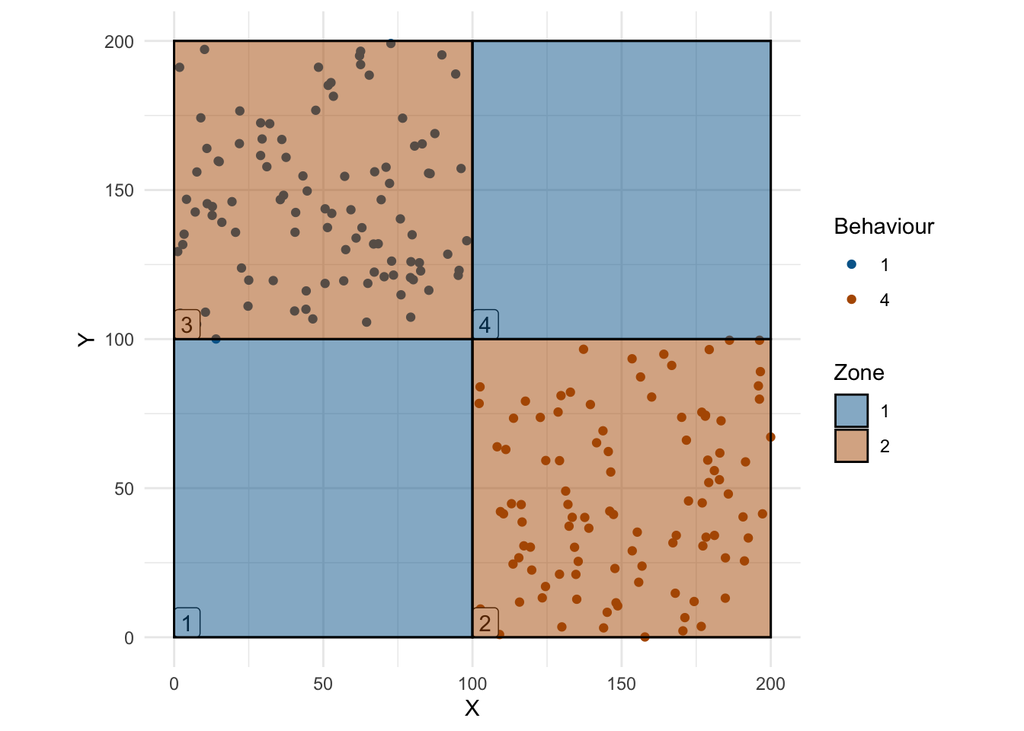

Figure 2: Simulated uneven data

```r
plot_grid(grid_uneven, obs, grid_col = TRUE, zone_fill = TRUE)
```

This gives the largest possible modified SPI of

```r
get_zone_object(grid_uneven, obs) |> calc_spi()
```

```
#> [1] 1
```

# Electivity Index

From @brereton-2022, we have
$$E = \frac{W_i - 1/n}{W_i + 1/n},$$
where
$$W_i = \frac{r_i/p_i}{\sum_{i=1}^nr_i/p_i},$$
where *n* is the number of zones, *r*<sub>*i*</sub> is the proportion number of observations in zone *i*, and *p*<sub>*i*</sub> is the expected proportion of observations based on equal grid use.

Consider the case of even spread (Figure 1), this gives a EI of

```r
get_zone_object(grid_even, obs) |>
  calc_ei() |>
  dplyr::select(zone, ei) |>
  gt::gt()
```

| zone | ei |
| --- | --- |
| 1 | 0 |
| 2 | 0 |

so zero for each zone. While in the case of uneven spread (Figure 2), we have an EI of

```r
get_zone_object(grid_uneven, obs) |>
  calc_ei() |>
  dplyr::select(zone, ei) |>
  gt::gt()
```

[output not shown]

Note that -1 indicates no use, and the 0.33 indicates sole use. The 0.33 is (*n* − 1)/(*n* + 1) which goes to 1 as *n* gets large